# Findings Summary

# 2 H1: Individual differences account for the divergence of trust in automation

## 2.1 Build Linear Models for H1

Metrics for evaluating goodness of fit: 1. RMSE 2. Akaike Information Criterion 3. Bayesian Information Criterion 4. Marginal R2 5. Conditional R2

## 2.2 Investigate the best Linear Mixed Effects Model (LMEM)

```r
#trust = reliability/propensity
ML1.lame = lme4::lmer(mean_trust_value ~ (reliability|propensity_value),
   data = f.df)

#trust = 1/propensity
ML2.lame = lme4::lmer(mean_trust_value ~ (1|propensity_value),
   data = f.df)

#trust = complacency + exposure + (reliability/propensity)
ML3.lame = lme4::lmer(mean_trust_value ~ complacency_value + exposure + (reliability|propensity_value),
    data = f.df)

#trust = reliability + exposure + (reliability/propensity)
ML4.lame = lme4::lmer(mean_trust_value ~ reliability + exposure + (reliability|propensity_value),
   data = f.df)

   #trust = reliability*exposure + (reliability/propensity)
ML5.lame = lme4::lmer(mean_trust_value ~ reliability*exposure+ (reliability|propensity_value),
   data = f.df)


trust.table = compare_performance(ML1.lame,ML2.lame, ML3.lame,ML4.lame, ML5.lame,rank = TRUE)
trust.table
```

```
# Comparison of Model Performance Indices

Name     |   Model |     AIC |     BIC | R2 (cond.) | R2 (marg.) |   ICC |  RMSE | Sigma | Performance-Score
------------------------------------------------------------------------------------------------------------
ML5.lame | lmerMod | 436.180 | 462.114 |      0.838 |      0.318 | 0.762 | 0.499 | 0.559 |           100.00%
ML4.lame | lmerMod | 454.761 | 477.453 |      0.810 |      0.293 | 0.731 | 0.537 | 0.599 |            91.75%
ML1.lame | lmerMod | 471.664 | 487.873 |      0.659 |      0.000 | 0.659 | 0.533 | 0.597 |            68.89%
ML3.lame | lmerMod | 478.270 | 500.962 |      0.669 |  8.370e-04 | 0.669 | 0.533 | 0.599 |            67.89%
ML2.lame | lmerMod | 610.877 | 620.602 |      0.387 |      0.000 | 0.387 | 1.026 | 1.079 |             0.00%
```

## 2.3 Select Best Performing LMEM based on the metrics

```r
BEST.lame = lme4::lmer(mean_trust_value ~ reliability*exposure + (reliability|propensity_value),
data = f.df)

summary(BEST.lame)## Report
```

```
Linear mixed model fit by REML ['lmerMod']
Formula:
mean_trust_value ~ reliability * exposure + (reliability | propensity_value)
   Data: f.df

REML criterion at convergence: 420.2

Scaled residuals:
    Min      1Q  Median      3Q     Max
-3.2294 -0.3978  0.0461  0.4013  3.7067

Random effects:
 Groups           Name           Variance
 propensity_value (Intercept)    0.7026
                  reliabilitylow 0.7555
 Residual                        0.3121
 Std.Dev. Corr
 0.8382
 0.8692   -0.03
 0.5586
Number of obs: 189, groups:
propensity_value, 21

Fixed effects:
                         Estimate Std. Error
(Intercept)                5.5749     0.2012
reliabilitylow            -1.1754     0.2254
exposure2                  0.2874     0.1101
reliabilitylow:exposure2  -0.9159     0.1884
                         t value
(Intercept)               27.704
reliabilitylow            -5.216
exposure2                  2.611
reliabilitylow:exposure2  -4.862

Correlation of Fixed Effects:
            (Intr) rlblty expsr2
reliabltylw -0.180
exposure2   -0.318  0.286
rlbltylw:x2  0.188 -0.303 -0.588
```

```r
report(BEST.lame)
```

[output not shown]

## 2.4 Investigate whether individual measures correlated with trust

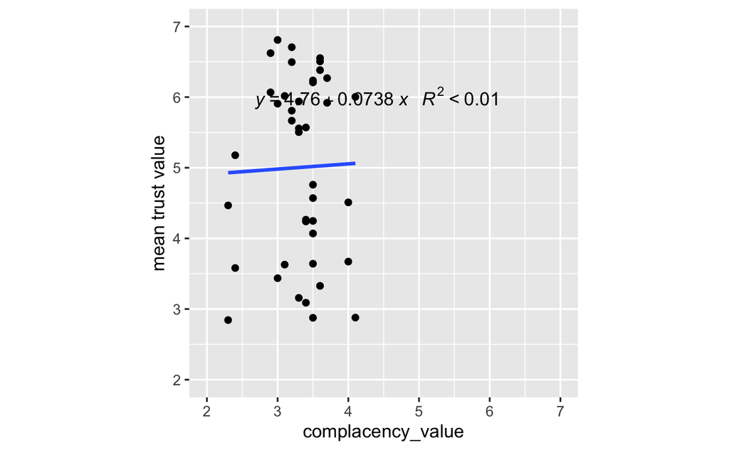

```r
prop = f.df %>%
  group_by(ID, reliability) %>%
  dplyr::select(propensity_value, mean_trust_value, reliability) %>%
  summarise(propensity_value, trust = mean(mean_trust_value, na.rm = TRUE), reliability) %>%
  distinct()
rel= f.df %>%
  group_by(ID) %>%
  dplyr::select(reliability, mean_trust_value, reliability) %>%
  summarise(reliability, trust = mean(mean_trust_value, na.rm = TRUE)) %>%
  distinct()
exp= f.df %>%
  group_by(ID) %>%
  dplyr::select(exposure, mean_trust_value) %>%
  summarise(exposure, trust = mean(mean_trust_value, na.rm = TRUE)) %>%
  distinct()
lcomp.plot = ggplot(comp, aes(complacency_value, trust))  +
  #facet_grid(~reliability) +
  geom_point() +
  coord_equal(xlim = c(2,7), ylim = c(2,7)) +
  geom_smooth(method='lm', se = FALSE) +
   stat_poly_eq(aes(label = paste(..eq.label.., ..rr.label.., sep = "~~~")),
               formula = formula, parse = TRUE,
               label.x = .8, label.y = .8 # scale 0-1 relative coordinates
               )  +
  ylab("mean trust value")

#
# ggplot(df,aes(x = wt, y = hp)) +
#   geom_point() +
#   geom_smooth(method = "lm", se=FALSE) +
#   geom_text(x = 2, y = 300, label = eq(df$wt,df$hp), parse = TRUE)

ecomp.plot = ggplot(eff, aes(efficacy_value, trust))  +
  #facet_grid(~reliability) +
  geom_point() +
  coord_equal(xlim = c(2,7), ylim = c(2,7)) +
  geom_smooth(method='lm', se = FALSE) +
  stat_poly_eq(aes(label = paste(..eq.label.., ..rr.label.., sep = "~~~")),
               formula = formula, parse = TRUE,
               label.x = .8, label.y = .8 # scale 0-1 relative coordinates
               )  +
  ylab("mean trust value")

tcomp.plot = ggplot(prop, aes(propensity_value, trust))  +
  #facet_grid(~reliability) +
  geom_point() +
  coord_equal(xlim = c(2,7), ylim = c(2,7)) +
  geom_smooth(method='lm', se = FALSE) +
  stat_poly_eq(aes(label = paste(..eq.label.., ..rr.label.., sep = "~~~")),
               formula = formula, parse = TRUE,
               label.x = .8, label.y = .8 # scale 0-1 relative coordinates
               )  +
  ylab("mean trust value")

change.df = f.df %>%
  group_by(ID, reliability, propensity_value) %>%
  summarise(trust = mean(mean_trust_value, na.rm = TRUE), ID, reliability, propensity_value, complacency_value, efficacy_value) %>%
  distinct() %>%
  pivot_wider(names_from = reliability, values_from = trust) %>%
  mutate(trust_diff = high-low)
#change.df

changep.plot = ggplot(change.df, aes(propensity_value, trust_diff)) +
  geom_point() +
     geom_smooth(method='lm', se = FALSE) +
   stat_poly_eq(aes(label = paste(..eq.label.., ..rr.label.., sep = "~~~")),
               formula = formula, parse = TRUE,
               label.x = .8, label.y = .8 # scale 0-1 relative coordinates
               )

changec.plot = ggplot(change.df, aes(complacency_value, trust_diff)) +
  geom_point() +
   geom_smooth(method='lm', se = FALSE) +
   stat_poly_eq(aes(label = paste(..eq.label.., ..rr.label.., sep = "~~~")),
               formula = formula, parse = TRUE,
               label.x = .8, label.y = .8 # scale 0-1 relative coordinates
               )

changeE.plot = ggplot(change.df, aes(efficacy_value, trust_diff)) +
  geom_point() +
    geom_smooth(method='lm', se = FALSE) +
   stat_poly_eq(aes(label = paste(..eq.label.., ..rr.label.., sep = "~~~")),
               formula = formula, parse = TRUE,
               label.x = .8, label.y = .8 # scale 0-1 relative coordinates
               )
#no correlation between propensity and drop in trust


lcomp.plot
```

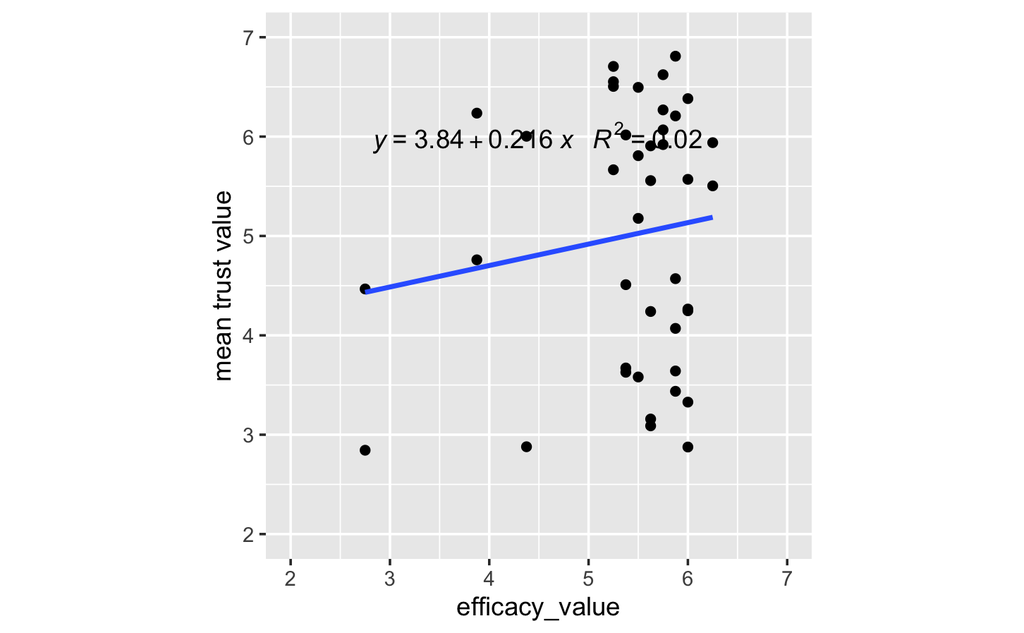

```r
ecomp.plot
```

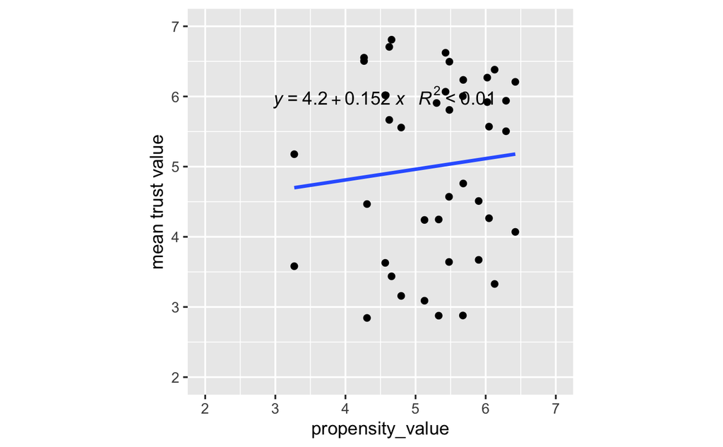

```r
tcomp.plot
```

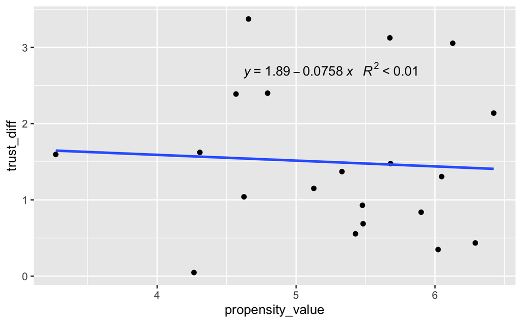

```r
changep.plot
```

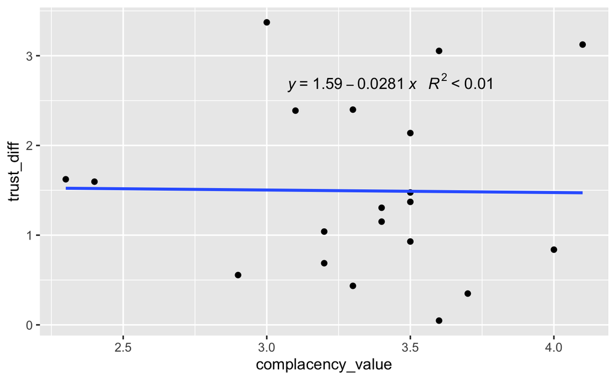

```r
changec.plot
```

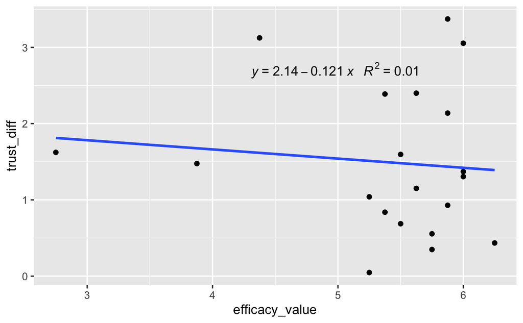

```r
changeE.plot
```

# 3 H2: Reliability and exposure account for differences in participants diverging trust in automation

The effect of reliability [low] is statistically significant and negative with respect to the effect of high reliability.

(beta = -1.18, 95% CI [-1.62, -0.73], t(181) = -5.22, p < .001; Std. beta = -0.86, 95% CI [-1.18, -0.54])

The effect of exposure [2] is statistically significant and positive with respect to exposure 1 (beta = 0.29, 95% CI [0.07, 0.50], t(181) = 2.61, p = 0.009; Std. beta = 0.21, 95% CI [0.05, 0.37])

The interaction effect of exposure [2] to reliability [low] is statistically significant and negative (beta = -0.92, 95% CI [-1.29, -0.55], t(181) = -4.86, p < .001; Std. beta = -0.67, 95% CI [-0.94, -0.40])

# 4 H3: Trust is a dynamic system. The combination of individual context, automation characteristics and experience and the interaction between the three factors account for the differences in the participant’s divering trust in automation

Since having the slope and intercept effect did improve the model performance, we provide support for H3 that a combination of individual differences and experimental conditions influences trust outcomes.